# Optimal Treatment Analysis

## Outcome Variable

**Outcome Variable:** ever_stunted

## Predictor Variables

**Intervention Variable:** earlybf

**Adjustment Set:**

- arm
- sex
- W_mage
- meducyrs
- feducyrs
- hhwealth_quart
- hfoodsec
- W_mhtcm
- vagbrth
- W_birthwt
- W_birthlen
- W_nrooms
- W_nchldlt5
- brthmon
- W_parity
- impfloor
- impsan
- safeh20
- delta_W_mage
- delta_meducyrs
- delta_feducyrs
- delta_hhwealth_quart
- delta_hfoodsec
- delta_W_mhtcm
- delta_vagbrth
- delta_W_birthwt
- delta_W_birthlen
- delta_W_nrooms
- delta_W_nchldlt5
- delta_brthmon
- delta_W_parity
- delta_impfloor
- delta_impsan
- delta_safeh20

## Stratifying Variables

The analysis was stratified on these variable(s):

- agecat
- studyid
- country

## Data Summary

| agecat | studyid | country | earlybf | ever_stunted | n_cell | n |
| --- | --- | --- | --- | --- | --- | --- |
| 0-24 months (no birth st.) | ki0047075b-MAL-ED | BANGLADESH | 0 | 0 | 38 | 216 |
| 0-24 months (no birth st.) | ki0047075b-MAL-ED | BANGLADESH | 0 | 1 | 40 | 216 |
| 0-24 months (no birth st.) | ki0047075b-MAL-ED | BANGLADESH | 1 | 0 | 66 | 216 |
| 0-24 months (no birth st.) | ki0047075b-MAL-ED | BANGLADESH | 1 | 1 | 72 | 216 |
| 0-24 months (no birth st.) | ki0047075b-MAL-ED | BRAZIL | 0 | 0 | 96 | 208 |
| 0-24 months (no birth st.) | ki0047075b-MAL-ED | BRAZIL | 0 | 1 | 12 | 208 |
| 0-24 months (no birth st.) | ki0047075b-MAL-ED | BRAZIL | 1 | 0 | 83 | 208 |
| 0-24 months (no birth st.) | ki0047075b-MAL-ED | BRAZIL | 1 | 1 | 17 | 208 |
| 0-24 months (no birth st.) | ki0047075b-MAL-ED | INDIA | 0 | 0 | 39 | 208 |
| 0-24 months (no birth st.) | ki0047075b-MAL-ED | INDIA | 0 | 1 | 41 | 208 |
| 0-24 months (no birth st.) | ki0047075b-MAL-ED | INDIA | 1 | 0 | 61 | 208 |
| 0-24 months (no birth st.) | ki0047075b-MAL-ED | INDIA | 1 | 1 | 67 | 208 |
| 0-24 months (no birth st.) | ki0047075b-MAL-ED | NEPAL | 0 | 0 | 92 | 212 |
| 0-24 months (no birth st.) | ki0047075b-MAL-ED | NEPAL | 0 | 1 | 30 | 212 |
| 0-24 months (no birth st.) | ki0047075b-MAL-ED | NEPAL | 1 | 0 | 65 | 212 |
| 0-24 months (no birth st.) | ki0047075b-MAL-ED | NEPAL | 1 | 1 | 25 | 212 |
| 0-24 months (no birth st.) | ki0047075b-MAL-ED | PERU | 0 | 0 | 30 | 266 |
| 0-24 months (no birth st.) | ki0047075b-MAL-ED | PERU | 0 | 1 | 34 | 266 |
| 0-24 months (no birth st.) | ki0047075b-MAL-ED | PERU | 1 | 0 | 85 | 266 |
| 0-24 months (no birth st.) | ki0047075b-MAL-ED | PERU | 1 | 1 | 117 | 266 |
| 0-24 months (no birth st.) | ki0047075b-MAL-ED | SOUTH AFRICA | 0 | 0 | 51 | 265 |
| 0-24 months (no birth st.) | ki0047075b-MAL-ED | SOUTH AFRICA | 0 | 1 | 47 | 265 |
| 0-24 months (no birth st.) | ki0047075b-MAL-ED | SOUTH AFRICA | 1 | 0 | 81 | 265 |
| 0-24 months (no birth st.) | ki0047075b-MAL-ED | SOUTH AFRICA | 1 | 1 | 86 | 265 |
| 0-24 months (no birth st.) | ki0047075b-MAL-ED | TANZANIA, UNITED REPUBLIC OF | 0 | 0 | 8 | 219 |
| 0-24 months (no birth st.) | ki0047075b-MAL-ED | TANZANIA, UNITED REPUBLIC OF | 0 | 1 | 27 | 219 |
| 0-24 months (no birth st.) | ki0047075b-MAL-ED | TANZANIA, UNITED REPUBLIC OF | 1 | 0 | 33 | 219 |
| 0-24 months (no birth st.) | ki0047075b-MAL-ED | TANZANIA, UNITED REPUBLIC OF | 1 | 1 | 151 | 219 |
| 0-24 months (no birth st.) | ki1000109-EE | PAKISTAN | 0 | 0 | 46 | 498 |
| 0-24 months (no birth st.) | ki1000109-EE | PAKISTAN | 0 | 1 | 354 | 498 |

[output cut: 138 more lines]

The following strata were considered:

- agecat: 0-24 months (no birth st.), studyid: ki0047075b-MAL-ED, country: BANGLADESH
- agecat: 0-24 months (no birth st.), studyid: ki0047075b-MAL-ED, country: BRAZIL
- agecat: 0-24 months (no birth st.), studyid: ki0047075b-MAL-ED, country: INDIA
- agecat: 0-24 months (no birth st.), studyid: ki0047075b-MAL-ED, country: NEPAL
- agecat: 0-24 months (no birth st.), studyid: ki0047075b-MAL-ED, country: PERU
- agecat: 0-24 months (no birth st.), studyid: ki0047075b-MAL-ED, country: SOUTH AFRICA
- agecat: 0-24 months (no birth st.), studyid: ki0047075b-MAL-ED, country: TANZANIA, UNITED REPUBLIC OF
- agecat: 0-24 months (no birth st.), studyid: ki1000109-EE, country: PAKISTAN
- agecat: 0-24 months (no birth st.), studyid: ki1000304b-SAS-CompFeed, country: INDIA
- agecat: 0-24 months (no birth st.), studyid: ki1017093c-NIH-Crypto, country: BANGLADESH
- agecat: 0-24 months (no birth st.), studyid: ki1113344-GMS-Nepal, country: NEPAL
- agecat: 0-24 months (no birth st.), studyid: ki1126311-ZVITAMBO, country: ZIMBABWE
- agecat: 0-24 months (no birth st.), studyid: kiGH5241-JiVitA-3, country: BANGLADESH
- agecat: 0-24 months (no birth st.), studyid: kiGH5241-JiVitA-4, country: BANGLADESH
- agecat: 0-6 months (no birth st.), studyid: ki0047075b-MAL-ED, country: BANGLADESH
- agecat: 0-6 months (no birth st.), studyid: ki0047075b-MAL-ED, country: BRAZIL
- agecat: 0-6 months (no birth st.), studyid: ki0047075b-MAL-ED, country: INDIA
- agecat: 0-6 months (no birth st.), studyid: ki0047075b-MAL-ED, country: NEPAL
- agecat: 0-6 months (no birth st.), studyid: ki0047075b-MAL-ED, country: PERU
- agecat: 0-6 months (no birth st.), studyid: ki0047075b-MAL-ED, country: SOUTH AFRICA
- agecat: 0-6 months (no birth st.), studyid: ki0047075b-MAL-ED, country: TANZANIA, UNITED REPUBLIC OF
- agecat: 0-6 months (no birth st.), studyid: ki1000109-EE, country: PAKISTAN
- agecat: 0-6 months (no birth st.), studyid: ki1000304b-SAS-CompFeed, country: INDIA
- agecat: 0-6 months (no birth st.), studyid: ki1017093c-NIH-Crypto, country: BANGLADESH
- agecat: 0-6 months (no birth st.), studyid: ki1113344-GMS-Nepal, country: NEPAL
- agecat: 0-6 months (no birth st.), studyid: ki1126311-ZVITAMBO, country: ZIMBABWE
- agecat: 0-6 months (no birth st.), studyid: kiGH5241-JiVitA-3, country: BANGLADESH
- agecat: 0-6 months (no birth st.), studyid: kiGH5241-JiVitA-4, country: BANGLADESH
- agecat: 6-24 months, studyid: ki0047075b-MAL-ED, country: BANGLADESH
- agecat: 6-24 months, studyid: ki0047075b-MAL-ED, country: BRAZIL
- agecat: 6-24 months, studyid: ki0047075b-MAL-ED, country: INDIA
- agecat: 6-24 months, studyid: ki0047075b-MAL-ED, country: NEPAL
- agecat: 6-24 months, studyid: ki0047075b-MAL-ED, country: PERU
- agecat: 6-24 months, studyid: ki0047075b-MAL-ED, country: SOUTH AFRICA
- agecat: 6-24 months, studyid: ki0047075b-MAL-ED, country: TANZANIA, UNITED REPUBLIC OF
- agecat: 6-24 months, studyid: ki1000109-EE, country: PAKISTAN
- agecat: 6-24 months, studyid: ki1000304b-SAS-CompFeed, country: INDIA
- agecat: 6-24 months, studyid: ki1017093c-NIH-Crypto, country: BANGLADESH
- agecat: 6-24 months, studyid: ki1113344-GMS-Nepal, country: NEPAL
- agecat: 6-24 months, studyid: ki1126311-ZVITAMBO, country: ZIMBABWE
- agecat: 6-24 months, studyid: kiGH5241-JiVitA-3, country: BANGLADESH
- agecat: 6-24 months, studyid: kiGH5241-JiVitA-4, country: BANGLADESH

### Dropped Strata

Some strata were dropped due to rare outcomes:

- agecat: 6-24 months, studyid: ki0047075b-MAL-ED, country: BRAZIL
- agecat: 6-24 months, studyid: kiGH5241-JiVitA-3, country: BANGLADESH

## Methods Detail

We’re interested in the causal parameters $E[Y_a]$ for all values of $a \in \mathcal{A}$. These parameters represent the mean outcome if, possibly contrary to fact, we intervened to set all units to have $A=a$. Under the randomization and positivity assumptions, these are identified by the statistical parameters $\psi_a=E_W[E_{Y|A,W}(Y|A=a,W)]$. In addition, we’re interested in the mean of $Y$, $E[Y]$ under no intervention (the observed mean). We will estimate these parameters by using SuperLearner to fit the relevant likelihood factors – $E_{Y|A,W}(Y|A=a,W)$ and $p(A=a|W)$, and then updating our likelihood fit using a joint TMLE.

For unadjusted analyses ($W=\{\}$), initial likelihoods were estimated using Lrnr_glm to estimate the simple $E(Y|A)$ and Lrnr_mean to estimate $p(A)$. For adjusted analyses, a small library containing Lrnr_glmnet, Lrnr_xgboost, and Lrnr_mean was used.

Having estimated these parameters, we will then use the delta method to estimate relative risks and attributable risks relative to a prespecified baseline level of $A$.

# Results Detail

## Results Plots

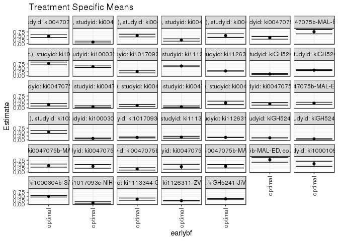

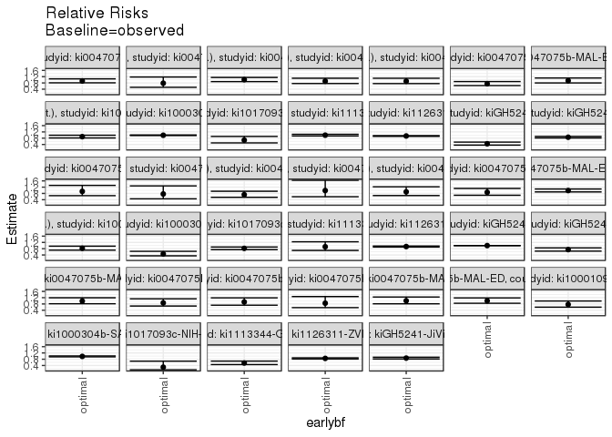

## Results Table

### Parameter: TSM

| agecat | studyid | country | intervention_level | baseline_level | estimate | ci_lower | ci_upper |
| --- | --- | --- | --- | --- | --- | --- | --- |
| 0-24 months (no birth st.) | ki0047075b-MAL-ED | BANGLADESH | optimal | NA | 0.4785389 | 0.3890675 | 0.5680102 |
| 0-24 months (no birth st.) | ki0047075b-MAL-ED | BRAZIL | optimal | NA | 0.1096675 | 0.0505999 | 0.1687351 |
| 0-24 months (no birth st.) | ki0047075b-MAL-ED | INDIA | optimal | NA | 0.5207148 | 0.4322433 | 0.6091863 |
| 0-24 months (no birth st.) | ki0047075b-MAL-ED | NEPAL | optimal | NA | 0.2385435 | 0.1670828 | 0.3100041 |
| 0-24 months (no birth st.) | ki0047075b-MAL-ED | PERU | optimal | NA | 0.5166669 | 0.4040202 | 0.6293137 |
| 0-24 months (no birth st.) | ki0047075b-MAL-ED | SOUTH AFRICA | optimal | NA | 0.3785960 | 0.2952165 | 0.4619755 |
| 0-24 months (no birth st.) | ki0047075b-MAL-ED | TANZANIA, UNITED REPUBLIC OF | optimal | NA | 0.7658222 | 0.6263784 | 0.9052660 |
| 0-24 months (no birth st.) | ki1000109-EE | PAKISTAN | optimal | NA | 0.7828565 | 0.6923609 | 0.8733522 |
| 0-24 months (no birth st.) | ki1000304b-SAS-CompFeed | INDIA | optimal | NA | 0.5721870 | 0.5173565 | 0.6270176 |
| 0-24 months (no birth st.) | ki1017093c-NIH-Crypto | BANGLADESH | optimal | NA | 0.2668437 | 0.1811415 | 0.3525459 |
| 0-24 months (no birth st.) | ki1113344-GMS-Nepal | NEPAL | optimal | NA | 0.6237871 | 0.5715048 | 0.6760693 |
| 0-24 months (no birth st.) | ki1126311-ZVITAMBO | ZIMBABWE | optimal | NA | 0.3051697 | 0.2942770 | 0.3160624 |
| 0-24 months (no birth st.) | kiGH5241-JiVitA-3 | BANGLADESH | optimal | NA | 0.1131355 | 0.0888538 | 0.1374172 |
| 0-24 months (no birth st.) | kiGH5241-JiVitA-4 | BANGLADESH | optimal | NA | 0.3595320 | 0.3335241 | 0.3855399 |
| 0-6 months (no birth st.) | ki0047075b-MAL-ED | BANGLADESH | optimal | NA | 0.1985411 | 0.1131621 | 0.2839200 |
| 0-6 months (no birth st.) | ki0047075b-MAL-ED | BRAZIL | optimal | NA | 0.0739838 | 0.0244725 | 0.1234950 |
| 0-6 months (no birth st.) | ki0047075b-MAL-ED | INDIA | optimal | NA | 0.1528973 | 0.0945774 | 0.2112172 |
| 0-6 months (no birth st.) | ki0047075b-MAL-ED | NEPAL | optimal | NA | 0.0664901 | 0.0162005 | 0.1167798 |
| 0-6 months (no birth st.) | ki0047075b-MAL-ED | PERU | optimal | NA | 0.3138824 | 0.2018102 | 0.4259546 |
| 0-6 months (no birth st.) | ki0047075b-MAL-ED | SOUTH AFRICA | optimal | NA | 0.2519231 | 0.1720842 | 0.3317621 |
| 0-6 months (no birth st.) | ki0047075b-MAL-ED | TANZANIA, UNITED REPUBLIC OF | optimal | NA | 0.2924607 | 0.2270734 | 0.3578481 |
| 0-6 months (no birth st.) | ki1000109-EE | PAKISTAN | optimal | NA | 0.5022293 | 0.4152593 | 0.5891993 |
| 0-6 months (no birth st.) | ki1000304b-SAS-CompFeed | INDIA | optimal | NA | 0.0926867 | 0.0653770 | 0.1199965 |
| 0-6 months (no birth st.) | ki1017093c-NIH-Crypto | BANGLADESH | optimal | NA | 0.1558878 | 0.1260337 | 0.1857420 |
| 0-6 months (no birth st.) | ki1113344-GMS-Nepal | NEPAL | optimal | NA | 0.1693710 | 0.1108091 | 0.2279330 |
| 0-6 months (no birth st.) | ki1126311-ZVITAMBO | ZIMBABWE | optimal | NA | 0.1595562 | 0.1509307 | 0.1681818 |
| 0-6 months (no birth st.) | kiGH5241-JiVitA-3 | BANGLADESH | optimal | NA | 0.1314562 | 0.1257892 | 0.1371232 |
| 0-6 months (no birth st.) | kiGH5241-JiVitA-4 | BANGLADESH | optimal | NA | 0.0638372 | 0.0522840 | 0.0753905 |
| 6-24 months | ki0047075b-MAL-ED | BANGLADESH | optimal | NA | 0.4081322 | 0.3095447 | 0.5067198 |
| 6-24 months | ki0047075b-MAL-ED | INDIA | optimal | NA | 0.3581371 | 0.2411525 | 0.4751216 |
| 6-24 months | ki0047075b-MAL-ED | NEPAL | optimal | NA | 0.1949145 | 0.1223226 | 0.2675064 |
| 6-24 months | ki0047075b-MAL-ED | PERU | optimal | NA | 0.3355577 | 0.1813454 | 0.4897700 |
| 6-24 months | ki0047075b-MAL-ED | SOUTH AFRICA | optimal | NA | 0.3640271 | 0.2550311 | 0.4730230 |
| 6-24 months | ki0047075b-MAL-ED | TANZANIA, UNITED REPUBLIC OF | optimal | NA | 0.7798434 | 0.6227019 | 0.9369850 |
| 6-24 months | ki1000109-EE | PAKISTAN | optimal | NA | 0.5234429 | 0.3625572 | 0.6843286 |
| 6-24 months | ki1000304b-SAS-CompFeed | INDIA | optimal | NA | 0.4921911 | 0.4452469 | 0.5391352 |
| 6-24 months | ki1017093c-NIH-Crypto | BANGLADESH | optimal | NA | 0.0769033 | 0.0110886 | 0.1427179 |
| 6-24 months | ki1113344-GMS-Nepal | NEPAL | optimal | NA | 0.3112988 | 0.2406301 | 0.3819675 |
| 6-24 months | ki1126311-ZVITAMBO | ZIMBABWE | optimal | NA | 0.2095082 | 0.1971106 | 0.2219058 |
| 6-24 months | kiGH5241-JiVitA-4 | BANGLADESH | optimal | NA | 0.3259343 | 0.3007740 | 0.3510947 |

### Parameter: E(Y)

| agecat | studyid | country | intervention_level | baseline_level | estimate | ci_lower | ci_upper |
| --- | --- | --- | --- | --- | --- | --- | --- |
| 0-24 months (no birth st.) | ki0047075b-MAL-ED | BANGLADESH | observed | NA | 0.5171784 | 0.4503900 | 0.5839668 |
| 0-24 months (no birth st.) | ki0047075b-MAL-ED | BRAZIL | observed | NA | 0.1401430 | 0.0929557 | 0.1873303 |
| 0-24 months (no birth st.) | ki0047075b-MAL-ED | INDIA | observed | NA | 0.5164198 | 0.4483567 | 0.5844828 |
| 0-24 months (no birth st.) | ki0047075b-MAL-ED | NEPAL | observed | NA | 0.2610173 | 0.2018745 | 0.3201601 |
| 0-24 months (no birth st.) | ki0047075b-MAL-ED | PERU | observed | NA | 0.5669652 | 0.5073192 | 0.6266111 |
| 0-24 months (no birth st.) | ki0047075b-MAL-ED | SOUTH AFRICA | observed | NA | 0.5046829 | 0.4443696 | 0.5649962 |
| 0-24 months (no birth st.) | ki0047075b-MAL-ED | TANZANIA, UNITED REPUBLIC OF | observed | NA | 0.8124434 | 0.7606615 | 0.8642253 |
| 0-24 months (no birth st.) | ki1000109-EE | PAKISTAN | observed | NA | 0.8720821 | 0.8298826 | 0.9142815 |
| 0-24 months (no birth st.) | ki1000304b-SAS-CompFeed | INDIA | observed | NA | 0.5800358 | 0.5274283 | 0.6326434 |
| 0-24 months (no birth st.) | ki1017093c-NIH-Crypto | BANGLADESH | observed | NA | 0.3952535 | 0.3577541 | 0.4327530 |
| 0-24 months (no birth st.) | ki1113344-GMS-Nepal | NEPAL | observed | NA | 0.6290927 | 0.5863416 | 0.6718438 |
| 0-24 months (no birth st.) | ki1126311-ZVITAMBO | ZIMBABWE | observed | NA | 0.3243253 | 0.3156650 | 0.3329855 |
| 0-24 months (no birth st.) | kiGH5241-JiVitA-3 | BANGLADESH | observed | NA | 0.2548390 | 0.2470184 | 0.2626597 |
| 0-24 months (no birth st.) | kiGH5241-JiVitA-4 | BANGLADESH | observed | NA | 0.4176914 | 0.3993874 | 0.4359954 |
| 0-6 months (no birth st.) | ki0047075b-MAL-ED | BANGLADESH | observed | NA | 0.2133679 | 0.1586438 | 0.2680920 |
| 0-6 months (no birth st.) | ki0047075b-MAL-ED | BRAZIL | observed | NA | 0.0965467 | 0.0563868 | 0.1367067 |
| 0-6 months (no birth st.) | ki0047075b-MAL-ED | INDIA | observed | NA | 0.2119469 | 0.1563120 | 0.2675819 |
| 0-6 months (no birth st.) | ki0047075b-MAL-ED | NEPAL | observed | NA | 0.0675378 | 0.0340284 | 0.1010473 |
| 0-6 months (no birth st.) | ki0047075b-MAL-ED | PERU | observed | NA | 0.3479589 | 0.2906909 | 0.4052269 |
| 0-6 months (no birth st.) | ki0047075b-MAL-ED | SOUTH AFRICA | observed | NA | 0.2880604 | 0.2335049 | 0.3426158 |
| 0-6 months (no birth st.) | ki0047075b-MAL-ED | TANZANIA, UNITED REPUBLIC OF | observed | NA | 0.2967223 | 0.2360776 | 0.3573670 |
| 0-6 months (no birth st.) | ki1000109-EE | PAKISTAN | observed | NA | 0.6092502 | 0.5483406 | 0.6701599 |
| 0-6 months (no birth st.) | ki1000304b-SAS-CompFeed | INDIA | observed | NA | 0.1981374 | 0.1740244 | 0.2222504 |
| 0-6 months (no birth st.) | ki1017093c-NIH-Crypto | BANGLADESH | observed | NA | 0.1901058 | 0.1600001 | 0.2202116 |
| 0-6 months (no birth st.) | ki1113344-GMS-Nepal | NEPAL | observed | NA | 0.1831078 | 0.1489117 | 0.2173039 |
| 0-6 months (no birth st.) | ki1126311-ZVITAMBO | ZIMBABWE | observed | NA | 0.1703661 | 0.1634082 | 0.1773240 |
| 0-6 months (no birth st.) | kiGH5241-JiVitA-3 | BANGLADESH | observed | NA | 0.1317418 | 0.1260967 | 0.1373868 |
| 0-6 months (no birth st.) | kiGH5241-JiVitA-4 | BANGLADESH | observed | NA | 0.0859414 | 0.0745818 | 0.0973010 |
| 6-24 months | ki0047075b-MAL-ED | BANGLADESH | observed | NA | 0.4140286 | 0.3368837 | 0.4911735 |
| 6-24 months | ki0047075b-MAL-ED | INDIA | observed | NA | 0.4125980 | 0.3348361 | 0.4903598 |
| 6-24 months | ki0047075b-MAL-ED | NEPAL | observed | NA | 0.2105916 | 0.1532506 | 0.2679325 |
| 6-24 months | ki0047075b-MAL-ED | PERU | observed | NA | 0.3957251 | 0.3169338 | 0.4745164 |
| 6-24 months | ki0047075b-MAL-ED | SOUTH AFRICA | observed | NA | 0.3631711 | 0.2877099 | 0.4386323 |
| 6-24 months | ki0047075b-MAL-ED | TANZANIA, UNITED REPUBLIC OF | observed | NA | 0.7793504 | 0.7116155 | 0.8470854 |
| 6-24 months | ki1000109-EE | PAKISTAN | observed | NA | 0.6828793 | 0.5895982 | 0.7761603 |
| 6-24 months | ki1000304b-SAS-CompFeed | INDIA | observed | NA | 0.5028831 | 0.4586572 | 0.5471090 |
| 6-24 months | ki1017093c-NIH-Crypto | BANGLADESH | observed | NA | 0.2628500 | 0.2244587 | 0.3012412 |
| 6-24 months | ki1113344-GMS-Nepal | NEPAL | observed | NA | 0.5579245 | 0.5087535 | 0.6070955 |
| 6-24 months | ki1126311-ZVITAMBO | ZIMBABWE | observed | NA | 0.2459553 | 0.2359391 | 0.2559714 |
| 6-24 months | kiGH5241-JiVitA-4 | BANGLADESH | observed | NA | 0.3747503 | 0.3560473 | 0.3934532 |

### Parameter: RR

| agecat | studyid | country | intervention_level | baseline_level | estimate | ci_lower | ci_upper |
| --- | --- | --- | --- | --- | --- | --- | --- |
| 0-24 months (no birth st.) | ki0047075b-MAL-ED | BANGLADESH | optimal | observed | 0.9252878 | 0.8073648 | 1.0604345 |
| 0-24 months (no birth st.) | ki0047075b-MAL-ED | BRAZIL | optimal | observed | 0.7825402 | 0.5203114 | 1.1769283 |
| 0-24 months (no birth st.) | ki0047075b-MAL-ED | INDIA | optimal | observed | 1.0083169 | 0.8840697 | 1.1500258 |
| 0-24 months (no birth st.) | ki0047075b-MAL-ED | NEPAL | optimal | observed | 0.9138990 | 0.7598021 | 1.0992487 |
| 0-24 months (no birth st.) | ki0047075b-MAL-ED | PERU | optimal | observed | 0.9112852 | 0.7572581 | 1.0966416 |
| 0-24 months (no birth st.) | ki0047075b-MAL-ED | SOUTH AFRICA | optimal | observed | 0.7501661 | 0.6328630 | 0.8892117 |
| 0-24 months (no birth st.) | ki0047075b-MAL-ED | TANZANIA, UNITED REPUBLIC OF | optimal | observed | 0.9426161 | 0.7991966 | 1.1117728 |
| 0-24 months (no birth st.) | ki1000109-EE | PAKISTAN | optimal | observed | 0.8976867 | 0.8149655 | 0.9888044 |
| 0-24 months (no birth st.) | ki1000304b-SAS-CompFeed | INDIA | optimal | observed | 0.9864684 | 0.9694404 | 1.0037956 |
| 0-24 months (no birth st.) | ki1017093c-NIH-Crypto | BANGLADESH | optimal | observed | 0.6751204 | 0.4992859 | 0.9128789 |
| 0-24 months (no birth st.) | ki1113344-GMS-Nepal | NEPAL | optimal | observed | 0.9915662 | 0.9396092 | 1.0463963 |
| 0-24 months (no birth st.) | ki1126311-ZVITAMBO | ZIMBABWE | optimal | observed | 0.9409373 | 0.9189974 | 0.9634010 |
| 0-24 months (no birth st.) | kiGH5241-JiVitA-3 | BANGLADESH | optimal | observed | 0.4439488 | 0.3582961 | 0.5500773 |
| 0-24 months (no birth st.) | kiGH5241-JiVitA-4 | BANGLADESH | optimal | observed | 0.8607599 | 0.8132435 | 0.9110525 |
| 0-6 months (no birth st.) | ki0047075b-MAL-ED | BANGLADESH | optimal | observed | 0.9305106 | 0.6590725 | 1.3137401 |
| 0-6 months (no birth st.) | ki0047075b-MAL-ED | BRAZIL | optimal | observed | 0.7662999 | 0.4581872 | 1.2816062 |
| 0-6 months (no birth st.) | ki0047075b-MAL-ED | INDIA | optimal | observed | 0.7213942 | 0.5536326 | 0.9399907 |
| 0-6 months (no birth st.) | ki0047075b-MAL-ED | NEPAL | optimal | observed | 0.9844874 | 0.5911020 | 1.6396754 |
| 0-6 months (no birth st.) | ki0047075b-MAL-ED | PERU | optimal | observed | 0.9020674 | 0.6653431 | 1.2230164 |
| 0-6 months (no birth st.) | ki0047075b-MAL-ED | SOUTH AFRICA | optimal | observed | 0.8745498 | 0.6841703 | 1.1179049 |
| 0-6 months (no birth st.) | ki0047075b-MAL-ED | TANZANIA, UNITED REPUBLIC OF | optimal | observed | 0.9856379 | 0.8974563 | 1.0824839 |
| 0-6 months (no birth st.) | ki1000109-EE | PAKISTAN | optimal | observed | 0.8243400 | 0.7079231 | 0.9599015 |
| 0-6 months (no birth st.) | ki1000304b-SAS-CompFeed | INDIA | optimal | observed | 0.4677902 | 0.3456767 | 0.6330415 |
| 0-6 months (no birth st.) | ki1017093c-NIH-Crypto | BANGLADESH | optimal | observed | 0.8200055 | 0.7399747 | 0.9086919 |
| 0-6 months (no birth st.) | ki1113344-GMS-Nepal | NEPAL | optimal | observed | 0.9249799 | 0.6900409 | 1.2399087 |
| 0-6 months (no birth st.) | ki1126311-ZVITAMBO | ZIMBABWE | optimal | observed | 0.9365493 | 0.9035064 | 0.9708007 |
| 0-6 months (no birth st.) | kiGH5241-JiVitA-3 | BANGLADESH | optimal | observed | 0.9978324 | 0.9949589 | 1.0007142 |
| 0-6 months (no birth st.) | kiGH5241-JiVitA-4 | BANGLADESH | optimal | observed | 0.7427997 | 0.6450429 | 0.8553718 |
| 6-24 months | ki0047075b-MAL-ED | BANGLADESH | optimal | observed | 0.9857585 | 0.8139131 | 1.1938866 |
| 6-24 months | ki0047075b-MAL-ED | INDIA | optimal | observed | 0.8680049 | 0.6686164 | 1.1268532 |
| 6-24 months | ki0047075b-MAL-ED | NEPAL | optimal | observed | 0.9255570 | 0.7209641 | 1.1882086 |
| 6-24 months | ki0047075b-MAL-ED | PERU | optimal | observed | 0.8479566 | 0.5656363 | 1.2711887 |
| 6-24 months | ki0047075b-MAL-ED | SOUTH AFRICA | optimal | observed | 1.0023570 | 0.8093586 | 1.2413773 |
| 6-24 months | ki0047075b-MAL-ED | TANZANIA, UNITED REPUBLIC OF | optimal | observed | 1.0006326 | 0.8447835 | 1.1852333 |
| 6-24 months | ki1000109-EE | PAKISTAN | optimal | observed | 0.7665234 | 0.5945301 | 0.9882731 |
| 6-24 months | ki1000304b-SAS-CompFeed | INDIA | optimal | observed | 0.9787386 | 0.9511365 | 1.0071416 |
| 6-24 months | ki1017093c-NIH-Crypto | BANGLADESH | optimal | observed | 0.2925748 | 0.1267522 | 0.6753335 |
| 6-24 months | ki1113344-GMS-Nepal | NEPAL | optimal | observed | 0.5579586 | 0.4587349 | 0.6786444 |
| 6-24 months | ki1126311-ZVITAMBO | ZIMBABWE | optimal | observed | 0.8518143 | 0.8161605 | 0.8890257 |
| 6-24 months | kiGH5241-JiVitA-4 | BANGLADESH | optimal | observed | 0.8697374 | 0.8168309 | 0.9260707 |